# Supervised Learning_R4_Project2_Thera Bank

```python
import pandas as pd
import numpy as np
import seaborn as sns
from scipy.stats import zscore
import scipy.stats as stats
import matplotlib.pyplot as plt
from sklearn.model_selection import train_test_split
from sklearn import metrics
from sklearn.preprocessing import MinMaxScaler
from sklearn import preprocessing
from sklearn.neighbors import KNeighborsClassifier
from sklearn.model_selection import cross_val_score
from scipy.stats import zscore
from sklearn.linear_model import LogisticRegression
from sklearn.metrics import roc_curve, auc
from sklearn.metrics import accuracy_score, confusion_matrix, recall_score, precision_score, f1_score, auc
from sklearn.naive_bayes import GaussianNB
from sklearn import model_selection
```

###### loading the dataset and checking the columns and rows

```python
bank_data = pd.read_csv("Bank_Personal_Loan_Modelling-1.csv")
bank_data.head()
```

|  | ID | Age | Experience | Income | ZIP Code | Family | CCAvg | Education | Mortgage | Personal Loan | Securities Account | CD Account | Online | CreditCard |
| --- | --- | --- | --- | --- | --- | --- | --- | --- | --- | --- | --- | --- | --- | --- |
| 0 | 1 | 25 | 1 | 49 | 91107 | 4 | 1.6 | 1 | 0 | 0 | 1 | 0 | 0 | 0 |
| 1 | 2 | 45 | 19 | 34 | 90089 | 3 | 1.5 | 1 | 0 | 0 | 1 | 0 | 0 | 0 |
| 2 | 3 | 39 | 15 | 11 | 94720 | 1 | 1.0 | 1 | 0 | 0 | 0 | 0 | 0 | 0 |
| 3 | 4 | 35 | 9 | 100 | 94112 | 1 | 2.7 | 2 | 0 | 0 | 0 | 0 | 0 | 0 |
| 4 | 5 | 35 | 8 | 45 | 91330 | 4 | 1.0 | 2 | 0 | 0 | 0 | 0 | 0 | 1 |

###### Exploratory Data Analysis

```python
bank_data.columns
```

```
Index(['ID', 'Age', 'Experience', 'Income', 'ZIP Code', 'Family', 'CCAvg',
       'Education', 'Mortgage', 'Personal Loan', 'Securities Account',
       'CD Account', 'Online', 'CreditCard'],
      dtype='object')
```

```python
bank_data.shape
```

```
(5000, 14)
```

```python
bank_data.info
```

[output not shown]

[output cut: 175 more lines]

###### checking for any missing values

```python
bank_data.isna().sum()
```

```
ID                    0
Age                   0
Experience            0
Income                0
ZIP Code              0
Family                0
CCAvg                 0
Education             0
Mortgage              0
Personal Loan         0
Securities Account    0
CD Account            0
Online                0
CreditCard            0
dtype: int64
```

```python
bank_data.dtypes
```

```
ID                      int64
Age                     int64
Experience              int64
Income                  int64
ZIP Code                int64
Family                  int64
CCAvg                 float64
Education               int64
Mortgage                int64
Personal Loan           int64
Securities Account      int64
CD Account              int64
Online                  int64
CreditCard              int64
dtype: object
```

there are no missing values on any column so moving further

```python
bank_data.describe().transpose()
```

|  | count | mean | std | min | 25% | 50% | 75% | max |
| --- | --- | --- | --- | --- | --- | --- | --- | --- |
| ID | 5000.0 | 2500.500000 | 1443.520003 | 1.0 | 1250.75 | 2500.5 | 3750.25 | 5000.0 |
| Age | 5000.0 | 45.338400 | 11.463166 | 23.0 | 35.00 | 45.0 | 55.00 | 67.0 |
| Experience | 5000.0 | 20.104600 | 11.467954 | -3.0 | 10.00 | 20.0 | 30.00 | 43.0 |
| Income | 5000.0 | 73.774200 | 46.033729 | 8.0 | 39.00 | 64.0 | 98.00 | 224.0 |
| ZIP Code | 5000.0 | 93152.503000 | 2121.852197 | 9307.0 | 91911.00 | 93437.0 | 94608.00 | 96651.0 |
| Family | 5000.0 | 2.396400 | 1.147663 | 1.0 | 1.00 | 2.0 | 3.00 | 4.0 |
| CCAvg | 5000.0 | 1.937938 | 1.747659 | 0.0 | 0.70 | 1.5 | 2.50 | 10.0 |
| Education | 5000.0 | 1.881000 | 0.839869 | 1.0 | 1.00 | 2.0 | 3.00 | 3.0 |
| Mortgage | 5000.0 | 56.498800 | 101.713802 | 0.0 | 0.00 | 0.0 | 101.00 | 635.0 |
| Personal Loan | 5000.0 | 0.096000 | 0.294621 | 0.0 | 0.00 | 0.0 | 0.00 | 1.0 |
| Securities Account | 5000.0 | 0.104400 | 0.305809 | 0.0 | 0.00 | 0.0 | 0.00 | 1.0 |
| CD Account | 5000.0 | 0.060400 | 0.238250 | 0.0 | 0.00 | 0.0 | 0.00 | 1.0 |
| Online | 5000.0 | 0.596800 | 0.490589 | 0.0 | 0.00 | 1.0 | 1.00 | 1.0 |
| CreditCard | 5000.0 | 0.294000 | 0.455637 | 0.0 | 0.00 | 0.0 | 1.00 | 1.0 |

###### checking unique values in the dataframe

```python
bank_data.apply(lambda x: len(x.unique()))
```

```
ID                    5000
Age                     45
Experience              47
Income                 162
ZIP Code               467
Family                   4
CCAvg                  108
Education                3
Mortgage               347
Personal Loan            2
Securities Account       2
CD Account               2
Online                   2
CreditCard               2
dtype: int64
```

It shows that there are fewer unique value present. so we need to clean the data more

```python
bank_data.groupby(["Personal Loan"]).count()
```

| Personal Loan | ID | Age | Experience | Income | ZIP Code | Family | CCAvg | Education | Mortgage | Securities Account | CD Account | Online | CreditCard |
| --- | --- | --- | --- | --- | --- | --- | --- | --- | --- | --- | --- | --- | --- |
| 0 | 4520 | 4520 | 4520 | 4520 | 4520 | 4520 | 4520 | 4520 | 4520 | 4520 | 4520 | 4520 | 4520 |
| 1 | 480 | 480 | 480 | 480 | 480 | 480 | 480 | 480 | 480 | 480 | 480 | 480 | 480 |

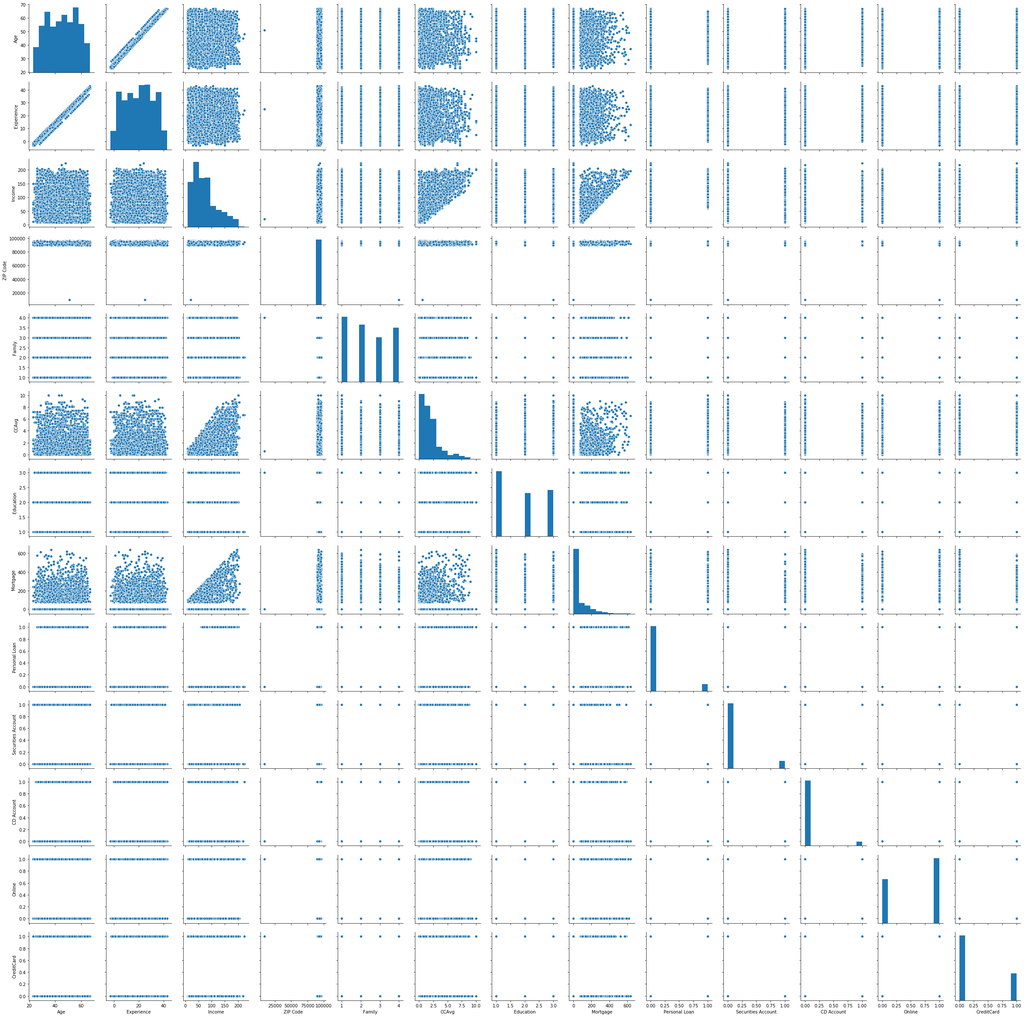

```python
sns.pairplot(bank_data.iloc[:,1:])
```

###### Cleaning the negative values from the Experience column

```python
#check the ammount of negative values
bank_data[bank_data['Experience'] < 0]['Experience'].value_counts()
```

```
-1    33
-2    15
-3     4
Name: Experience, dtype: int64
```

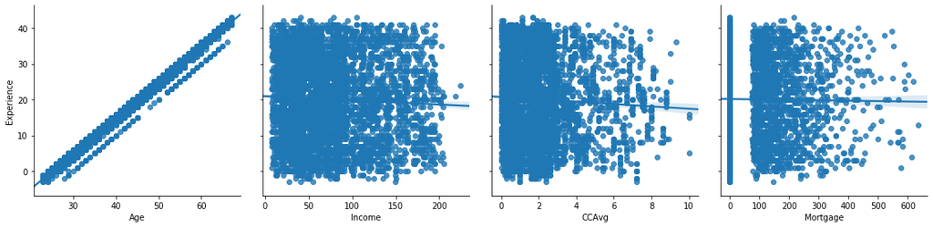

```python
ncol = ['Age', 'Income','CCAvg', 'Mortgage']
grid = sns.PairGrid(bank_data, y_vars = 'Experience', x_vars = ncol, height = 4)
grid.map(sns.regplot);
```

'Age' has a very strong association with Experience.

Get the subset of 'Age' data with negative values in 'Experience

```python
bank_data[bank_data['Experience'] < 0]['Age'].value_counts()
```

```
25    18
24    17
23    12
29     3
28     1
26     1
Name: Age, dtype: int64
```

Observation:

The subset of each Age with negative values in 'Experience' is definitely small.

Decision: We can replace each negative 'Experience' value with the mean of positive 'Experience' value associated with the particular 'Age' value

```python
# Get a list of 'Age' values where we found some negative values in 'Experience'
ages = bank_data[bank_data['Experience'] < 0]['Age'].unique().tolist()
ages
```

```
[25, 24, 28, 23, 29, 26]
```

```python
indexes = bank_data[bank_data['Experience'] < 0].index.tolist()
```

```python
for i in indexes:
    for x in ages:
        bank_data.loc[i,'Experience'] = bank_data[(bank_data.Age == x) & (bank_data.Experience > 0)].Experience.mean()
```

```python
bank_data[bank_data['Experience'] < 0]['Age'].value_counts()
```

```
Series([], Name: Age, dtype: int64)
```

```python
bank_data.Experience.describe()
```

```
count    5000.000000
mean       20.135743
std        11.413140
min         0.000000
25%        10.000000
50%        20.000000
75%        30.000000
max        43.000000
Name: Experience, dtype: float64
```

```python
# checking back again if there is any negative value present in the experience column
bank_data[bank_data['Experience'] < 0]['Experience'].value_counts()
```

```
Series([], Name: Experience, dtype: int64)
```

###### Checking skewness and distribution for respective columns

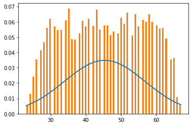

```
Skew = -0.02934068151284029
```

```python
#convert bank data DataFrame object to numpy array and sort
numpydf = np.asarray(bank_data['Age'])
numpydf = sorted(numpydf)

#use the scipy stats module to fit a normal distirbution with same mean and standard deviation
fit = stats.norm.pdf(numpydf, np.mean(numpydf), np.std(numpydf))

#plot both series on the histogram
plt.plot(numpydf ,fit,'-',linewidth = 2)
plt.hist(numpydf, normed=True, bins = 100)
plt.show()

print('Skew =', bank_data['Age'].skew())
```

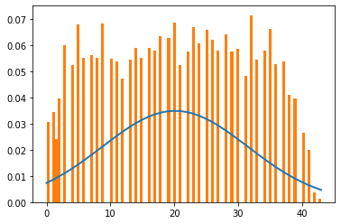

```
Skew = -0.009387084385113416
```

```python
#convert bank data DataFrame object to numpy array and sort
numpydf = np.asarray(bank_data['Experience'])
numpydf = sorted(numpydf)

#use the scipy stats module to fit a normal distirbution with same mean and standard deviation
fit = stats.norm.pdf(numpydf, np.mean(numpydf), np.std(numpydf))

#plot both series on the histogram
plt.plot(numpydf ,fit,'-',linewidth = 2)
plt.hist(numpydf, normed=True, bins = 100)
plt.show()

print('Skew =', bank_data['Experience'].skew())
```

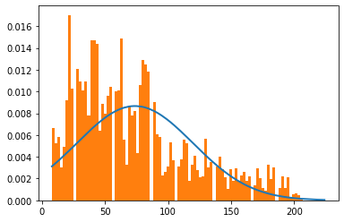

```
Skew = 0.8413386072610816
```

```python
#convert bank data DataFrame object to numpy array and sort
numpydf = np.asarray(bank_data['Income'])
numpydf = sorted(numpydf)

#use the scipy stats module to fit a normal distirbution with same mean and standard deviation
fit = stats.norm.pdf(numpydf, np.mean(numpydf), np.std(numpydf))

#plot both series on the histogram
plt.plot(numpydf ,fit,'-',linewidth = 2)
plt.hist(numpydf, normed=True, bins = 100)
plt.show()

print('Skew =', bank_data['Income'].skew())
```

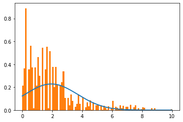

```
Skew = 1.5984433366678663
```

```python
#convert bank data DataFrame object to numpy array and sort
numpydf = np.asarray(bank_data['CCAvg'])
numpydf = sorted(numpydf)

#use the scipy stats module to fit a normal distirbution with same mean and standard deviation
fit = stats.norm.pdf(numpydf, np.mean(numpydf), np.std(numpydf))

#plot both series on the histogram
plt.plot(numpydf ,fit,'-',linewidth = 2)
plt.hist(numpydf, normed=True, bins = 100)
plt.show()

print('Skew =', bank_data['CCAvg'].skew())
```

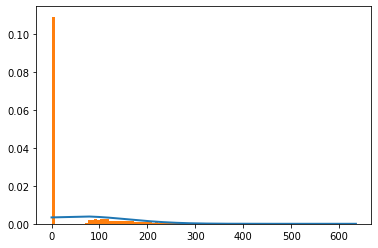

```
Skew = 2.1040023191079444
```

```python
#convert bank data DataFrame object to numpy array and sort
numpydf = np.asarray(bank_data['Mortgage'])
numpydf = sorted(numpydf)

#use the scipy stats module to fit a normal distirbution with same mean and standard deviation
fit = stats.norm.pdf(numpydf, np.mean(numpydf), np.std(numpydf))

#plot both series on the histogram
plt.plot(numpydf ,fit,'-',linewidth = 2)
plt.hist(numpydf, normed=True, bins = 100)
plt.show()

print('Skew =', bank_data['Mortgage'].skew())
```

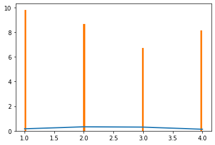

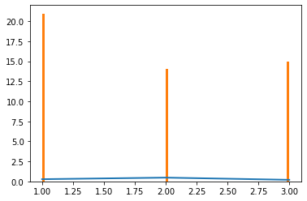

```
Skewness in Education Column = 0.22709331566088503
Skewness in Family Column = 0.15522066944367582
```

```python
#convert bank data DataFrame object to numpy array and sort
numpydf = np.asarray(bank_data['Family'])
numpydf = sorted(numpydf)

#use the scipy stats module to fit a normal distirbution with same mean and standard deviation
fit = stats.norm.pdf(numpydf, np.mean(numpydf), np.std(numpydf))

#plot both series on the histogram
plt.plot(numpydf ,fit,'-',linewidth = 2)
plt.hist(numpydf, normed=True, bins = 100)
plt.show()

numpydf1 = np.asarray(bank_data['Education'])
numpydf1 = sorted(numpydf1)

#use the scipy stats module to fit a normal distirbution with same mean and standard deviation
fit = stats.norm.pdf(numpydf1, np.mean(numpydf1), np.std(numpydf1))

#plot both series on the histogram
plt.plot(numpydf1,fit,'-',linewidth = 2)
plt.hist(numpydf1, normed=True, bins = 100)
plt.show()

print('Skewness in Education Column =', bank_data['Education'].skew())

print('Skewness in Family Column =', bank_data['Family'].skew())
```

```python
# checking back again the 5 point Summary
#bank_data.describe().T
bank_data.isna().sum()
```

```
ID                    0
Age                   0
Experience            0
Income                0
ZIP Code              0
Family                0
CCAvg                 0
Education             0
Mortgage              0
Personal Loan         0
Securities Account    0
CD Account            0
Online                0
CreditCard            0
dtype: int64
```

###### Distributions of personal loans value among groups of CD Account values

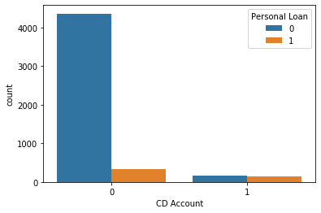

```python
sns.countplot(x='CD Account',data=bank_data,hue='Personal Loan')
```

```python
series = bank_data[bank_data['CD Account'] == 1]['Personal Loan'].value_counts()
```

[output not shown]

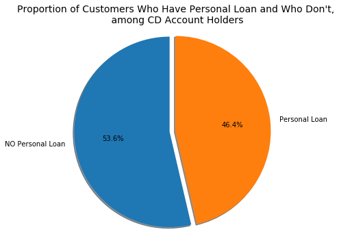

```python
plt.axis('equal')
plt.title('Proportion of Customers Who Have Personal Loan and Who Don\'t,\n among CD Account Holders', \
          fontsize = 14, y = 1.2)
labels = ['NO Personal Loan','Personal Loan']
plt.pie(series, labels = labels,autopct= '%1.1f%%', shadow = True,explode = (0.1, 0), radius = 1.6, startangle = 90)
```

46.4% of CD Account Holders have Perconal Loan. For 'CD Account' characteristic - the main segment to sell Personal Loan is the people who already have a CD Account with the Bank.

###### Distributions of Personal Loan among group of Education

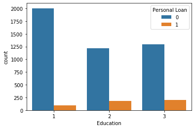

```python
sns.countplot(x="Education", data=bank_data,hue="Personal Loan")
```

We may say that the proportion of persons who has Personal Loan among them who has Third and Second Level of Education is higher than proportion among people who has First level of Education. Checking the number of proportion

```python
education = bank_data[bank_data['Personal Loan'] == 1]['Education'].value_counts()
education
```

```
3    205
2    182
1     93
Name: Education, dtype: int64
```

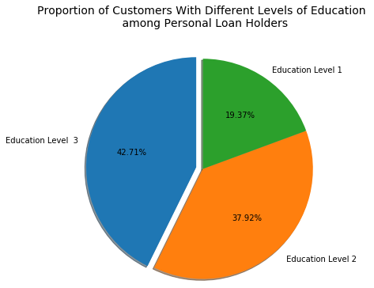

```python
plt.axis('equal')
plt.title('Proportion of Customers With Different Levels of Education \n among Personal Loan Holders', \
          fontsize = 14, y = 1.3)
labels = ['Education Level  3',' Education Level 2','Education Level 1']
plt.pie(education, labels = labels, autopct= '%1.2f%%', shadow = True,explode = (0.1, 0, 0), radius = 1.6, startangle = 90);
plt.savefig('Proportion_edu_levels_among_PL.png', bbox_inches = 'tight');
```

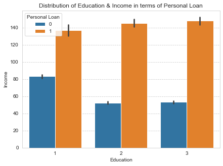

```python
sns.set_style("whitegrid", {'grid.linestyle': '--'})
plt.figure(figsize = (7,5))
sns.barplot(x = "Education", y = "Income", hue='Personal Loan', data = bank_data)
plt.xlabel("Education")
plt.ylabel("Income")
plt.title("Distribution of Education & Income in terms of Personal Loan")
```

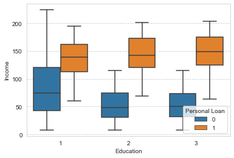

```python
sns.boxplot(x='Education',y='Income',hue='Personal Loan',data=bank_data)
```

Observation : From the above two graphs, it seems the customers whose education level is 1 is having more income. However customers who has taken the personal loan have the same income levels

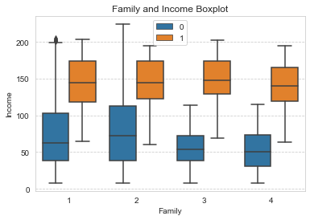

```python
sns.boxplot(x='Family',data=bank_data,hue='Personal Loan',y='Income')
plt.legend(loc='upper center')
plt.title("Family and Income Boxplot")
```

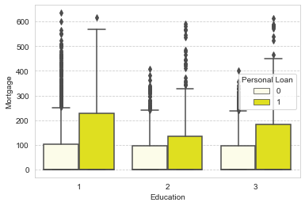

```python
sns.boxplot(x="Education", y='Mortgage', hue="Personal Loan", data=bank_data,color='yellow')
```

###### Inference : From the above chart it seems that customer who do not have personal loan and customer who has personal loan have high mortgage

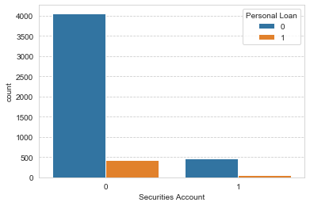

```python
sns.countplot(x="Securities Account", data=bank_data,hue="Personal Loan")
```

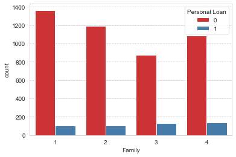

```python
sns.countplot(x='Family',data=bank_data,hue='Personal Loan',palette='Set1')
```

###### Observation: Family size does not have any impact in personal loan. But it seems families with size of 3 are more likely to take loan. When considering future campaign this might be good association.

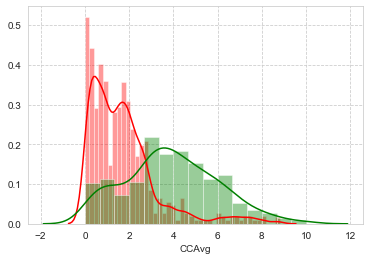

```python
sns.distplot( bank_data[bank_data['Personal Loan'] == 0]['CCAvg'], color = 'r')
sns.distplot( bank_data[bank_data['Personal Loan'] == 1]['CCAvg'], color = 'g')
```

```python
print('Credit card spending of Non-Loan customers: ',bank_data[bank_data['Personal Loan'] == 0]['CCAvg'].median()*1000)
print('Credit card spending of Loan customers    : ', bank_data[bank_data['Personal Loan'] == 1]['CCAvg'].median()*1000)
```

```
Credit card spending of Non-Loan customers:  1400.0
Credit card spending of Loan customers    :  3800.0
```

###### Observation: The graph above shows that the persons who have personal loan have a higher credit card average. Average credit card spending with a median of 3800 dollar indicates a higher probability of personal loan. Lower credit card spending with a median of 1400 dollars is less likely to take a loan. This could be useful information.

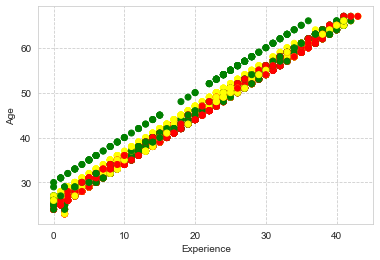

```python
fig, ax = plt.subplots()
colors = {1:'red',2:'yellow',3:'green'}
ax.scatter(bank_data['Experience'],bank_data['Age'],c=bank_data['Education'].apply(lambda x:colors[x]))
plt.xlabel('Experience')
plt.ylabel('Age')
```

###### Observation: The above plot shows that experience and age has a positive correlation. As experience increase age also increases. Also the colors show the education level. There is gap in the mid forties of age and also more people in the under graduate level

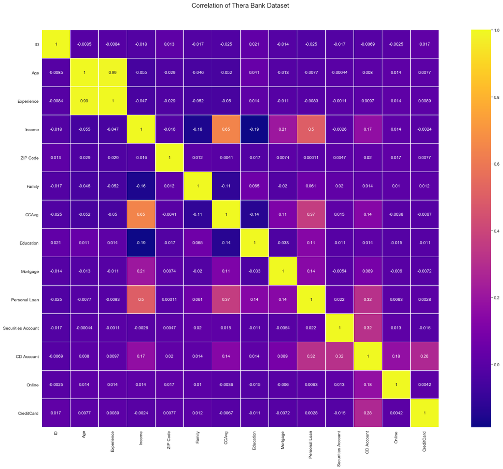

```python
colormap = plt.cm.plasma
plt.figure(figsize=(27,17))
plt.title('Correlation of Thera Bank Dataset', y=1.05, size=15)
sns.heatmap(bank_data.corr(),linewidths=0.1,vmax=1.0, square=True, cmap=colormap,
            linecolor='white', annot=True)
```

1. Income and CCAvg is moderately correlated.
2. Age and Experience is highly correlated

```python
X = bank_data.drop(["ZIP Code", "ID", "Personal Loan"] , axis = 1)
X.head()
```

|  | Age | Experience | Income | Family | CCAvg | Education | Mortgage | Securities Account | CD Account | Online | CreditCard |
| --- | --- | --- | --- | --- | --- | --- | --- | --- | --- | --- | --- |
| 0 | 25 | 1.0 | 49 | 4 | 1.6 | 1 | 0 | 1 | 0 | 0 | 0 |
| 1 | 45 | 19.0 | 34 | 3 | 1.5 | 1 | 0 | 1 | 0 | 0 | 0 |
| 2 | 39 | 15.0 | 11 | 1 | 1.0 | 1 | 0 | 0 | 0 | 0 | 0 |
| 3 | 35 | 9.0 | 100 | 1 | 2.7 | 2 | 0 | 0 | 0 | 0 | 0 |
| 4 | 35 | 8.0 | 45 | 4 | 1.0 | 2 | 0 | 0 | 0 | 0 | 1 |

```python
y=bank_data[['Personal Loan']]
y.head()
```

|  | Personal Loan |
| --- | --- |
| 0 | 0 |
| 1 | 0 |
| 2 | 0 |
| 3 | 0 |
| 4 | 0 |

```python
#mm_scaler = preprocessing.MinMaxScaler()
#X = mm_scaler.fit_transform(X)
#X
X = X.apply(zscore)
```

```python
test_size=0.30
seed=7
X_train, X_test, y_train, y_test=train_test_split(X, y, test_size=test_size, random_state=seed)
```

```python
X_train.shape
```

```
(3500, 11)
```

```python
X_test.shape
```

```
(1500, 11)
```

```python
y_train.shape
```

```
(3500, 1)
```

```python
y_test.shape
```

```
(1500, 1)
```

# KNN Algorithm

```python
test_size=0.30
seed=7
X_train, X_test, y_train, y_test=train_test_split(X, y, test_size=test_size, random_state=seed)
KNNH=KNeighborsClassifier()
KNNH.fit(X_train, y_train)
# For every test data point, predict it's label based on 5 nearest neighbours in this model. The majority class will
# be assigned to the test data point
predicted_labels = KNNH.predict(X_train)
## Train Accuracy
print("Score for training data is =", KNNH.score(X_train, y_train))
## Test accuracy
print("Score for test data is =", KNNH.score(X_test, y_test))
```

```
Score for training data is = 0.9694285714285714
Score for test data is = 0.9593333333333334
```

## Finding Optimal K

```python
maxK = int(np.sqrt(X_train.shape[0]))
maxK
```

```
59
```

```python
# creating odd list of K for KNN
myList = list(range(1,60))
```

```python
# subsetting just the odd ones
neighbors = list(filter(lambda x: x % 2 != 0, myList))
```

```python
# empty list that will hold cv scores
cv_scores = []
```

```python
# perform 10-fold cross validation
for k in neighbors:
    knn = KNeighborsClassifier(n_neighbors=k)
    scores = cross_val_score(knn, X_train, y_train.values.ravel(), cv=10, scoring='accuracy') #used ravel() as it was giving warnings
    cv_scores.append(scores.mean())
```

```python
# changing to misclassification error
misError = [1 - x for x in cv_scores]
```

```python
optimal_k = neighbors[misError.index(min(misError))]
print("The value of optimal K is = ",optimal_k)
```

```
The value of optimal K is =  5
```

```python
NNH = KNeighborsClassifier(n_neighbors=optimal_k)
NNH.fit(X_train, y_train)
print(NNH.score(X_train, y_train))
print(NNH.score(X_test, y_test))
```

```
0.9694285714285714
0.9593333333333334
```

```python
# Confusion matrix
knn_cm=metrics.confusion_matrix(y_test, NNH.predict(X_test))
knn_cm
```

```
array([[1354,    8],
       [  53,   85]], dtype=int64)
```

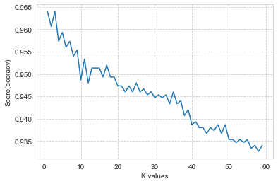

```python
#find avaible value of k
score_list=[]
k_value=[]
for i in myList:
    knn_available=KNeighborsClassifier(n_neighbors=i)
    knn_available.fit(X_train,y_train.values.ravel())

    score_list.append(knn_available.score(X_test,y_test))
    k_value.append(i)
plt.plot(myList,score_list)
plt.xlabel("K values")
plt.ylabel("Score(accracy)")
plt.show()
```

```python
y_predictProb = KNNH.predict_proba(X_test)
```

```python
fpr, tpr, thresholds = roc_curve(y_test, y_predictProb[::,1])
```

```python
roc_auc = auc(fpr, tpr)
roc_auc
```

```
0.9295127583051351
```

```python
optimalF1 = 0
optimalTh = 0
```

```python
for th in thresholds:
    preds = np.where(KNNH.predict_proba(X_test)[:,1] > th, 1, 0)
    f1Score = f1_score(y_test, preds)
    if(optimalF1 < f1Score):
        optimalF1 = f1Score
        optimalTh = th
```

```python
THRESHOLD = optimalTh
```

```python
preds = np.where(KNNH.predict_proba(X_test)[:,1] > THRESHOLD, 1, 0)
```

```python
pd.DataFrame(data=[accuracy_score(y_test, preds),
                   recall_score(y_test, preds),
                   precision_score(y_test, preds),
                   f1_score(y_test, preds)],
             index=["accuracy", "recall", "precision", "f1Score"])
```

|  | 0 |
| --- | --- |
| accuracy | 0.958667 |
| recall | 0.775362 |
| precision | 0.775362 |
| f1Score | 0.775362 |

# Model Using Logistic Regression

```python
model = LogisticRegression()
model.fit(X_train, y_train)
y_predict = model.predict(X_test)
print("Logistic Regression Model Score for Train Data=", model.score(X_train, y_train)) #Train Classification accuracy
print("Logistic Regression Model Score for Test Data=",model.score(X_test, y_test)) #Test Classification accuracy
```

```
Logistic Regression Model Score for Train Data= 0.9522857142857143
Logistic Regression Model Score for Test Data= 0.9546666666666667
```

```python
metrics.confusion_matrix(y_predict, y_test)
```

```
array([[1343,   49],
       [  19,   89]], dtype=int64)
```

```python
model.predict_proba(X_train)
```

```
array([[0.99355274, 0.00644726],
       [0.99475044, 0.00524956],
       [0.99455123, 0.00544877],
       ...,
       [0.60487773, 0.39512227],
       [0.67450076, 0.32549924],
       [0.88935441, 0.11064559]])
```

```python
y_predictProb = model.predict_proba(X_train)
```

```python
fpr, tpr, thresholds = roc_curve(y_train, y_predictProb[::,1])
```

```python
roc_auc = auc(fpr, tpr)
roc_auc
```

```
0.9557922143335963
```

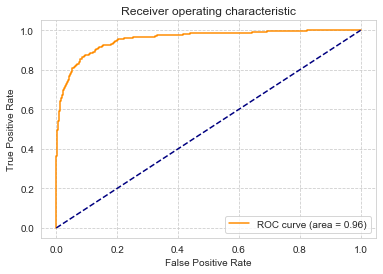

```python
plt.plot(fpr, tpr, color='darkorange', label='ROC curve (area = %0.2f)' % roc_auc)
plt.plot([0, 1], [0, 1], color='navy', linestyle='--')
plt.xlabel('False Positive Rate')
plt.ylabel('True Positive Rate')
plt.title('Receiver operating characteristic')
plt.legend(loc="lower right")
```

```python
optimalF1 = 0
optimalTh = 0
```

```python
thresholds[0:10]
```

```
array([1.99961296, 0.99961296, 0.98809202, 0.98802929, 0.91066534,
       0.91016725, 0.8521167 , 0.84391326, 0.84076329, 0.83964263])
```

```python
for th in thresholds:
    preds = np.where(model.predict_proba(X_train)[:,1] > th, 1, 0)
    f1Score = f1_score(y_train, preds)
    if(optimalF1 < f1Score):
        optimalF1 = f1Score
        optimalTh = th
```

```python
optimalF1
```

```
0.72782874617737
```

```python
optimalTh
```

```
0.363702920468551
```

```python
THRESHOLD = optimalTh
```

```python
preds = np.where(model.predict_proba(X_test)[:,1] > THRESHOLD, 1, 0)
```

```python
pd.DataFrame(data=[accuracy_score(y_test, preds),
                   recall_score(y_test, preds),
                   precision_score(y_test, preds),
                   f1_score(y_test, preds)],
             index=["accuracy", "recall", "precision", "f1_score"])
```

|  | 0 |
| --- | --- |
| accuracy | 0.952000 |
| recall | 0.710145 |
| precision | 0.753846 |
| f1_score | 0.731343 |

# Naive Bayes

```python
model_naive = GaussianNB()
```

```python
model_naive.fit(X_train, y_train)
```

```
GaussianNB(priors=None, var_smoothing=1e-09)
```

```python
# make predictions
predicted = model_naive.predict(X_test)
```

```python
metrics.confusion_matrix(predicted, y_test)
```

```
array([[1237,   56],
       [ 125,   82]], dtype=int64)
```

```python
print("Train Accuracy for Naive Bayes is = ", model_naive.score(X_train, y_train))
```

```
Train Accuracy for Naive Bayes is =  0.8817142857142857
```

```python
print("Test Accuracy for Naive Bayes is = ", model_naive.score(X_test, y_test))
```

```
Test Accuracy for Naive Bayes is =  0.8793333333333333
```

```python
y_predictProb = model_naive.predict_proba(X_test)
```

```python
fpr, tpr, thresholds = roc_curve(y_test, y_predictProb[::,1])
```

```python
roc_auc = auc(fpr, tpr)
roc_auc
```

```
0.9256208899955308
```

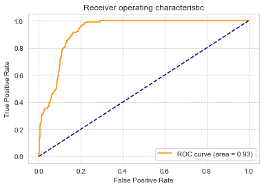

```python
plt.plot(fpr, tpr, color='darkorange', label='ROC curve (area = %0.2f)' % roc_auc)
plt.plot([0, 1], [0, 1], color='navy', linestyle='--')
plt.xlabel('False Positive Rate')
plt.ylabel('True Positive Rate')
plt.title('Receiver operating characteristic')
plt.legend(loc="lower right")
```

```python
optimalF1 = 0
optimalTh = 0
```

```python
for th in thresholds:
    preds = np.where(model_naive.predict_proba(X_test)[:,1] > th, 1, 0)
    f1Score = f1_score(y_test, preds)
    if(optimalF1 < f1Score):
        optimalF1 = f1Score
        optimalTh = th
```

```python
optimalF1
```

```
0.542713567839196
```

```python
optimalTh
```

```
0.13572558497541573
```

```python
THRESHOLD = optimalTh
```

```python
preds = np.where(model_naive.predict_proba(X_test)[:,1] > THRESHOLD, 1, 0)
```

```python
pd.DataFrame(data=[accuracy_score(y_test, preds),
                   recall_score(y_test, preds),
                   precision_score(y_test, preds),
                   f1_score(y_test, preds)],
             index=["accuracy", "recall", "precision", "f1Score"])
```

|  | 0 |
| --- | --- |
| accuracy | 0.878667 |
| recall | 0.782609 |
| precision | 0.415385 |
| f1Score | 0.542714 |

```
KNN: 0.960200 (0.007666)
NB: 0.883200 (0.011496)
LR: 0.951400 (0.006003)
```

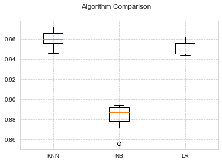

```python
models = []
models.append(('KNN', KNeighborsClassifier()))
models.append(('NB', GaussianNB()))
models.append(('LR', LogisticRegression()))
# evaluate each model in turn
results = []
names = []
scoring = 'accuracy'
for name, model in models:
	kfold = model_selection.KFold(n_splits=10, random_state=12345)
	cv_results = model_selection.cross_val_score(model, X, y.values.ravel(), cv=kfold, scoring=scoring)
	results.append(cv_results)
	names.append(name)
	msg = "%s: %f (%f)" % (name, cv_results.mean(), cv_results.std())
	print(msg)
# boxplot algorithm comparison
fig = plt.figure()
fig.suptitle('Algorithm Comparison')
ax = fig.add_subplot(111)
plt.boxplot(results)
ax.set_xticklabels(names)
plt.show()
```

From the above figure, and from the model accuracy score that we have evaluated for each respective model(KNN, Logistic Regression, Naive Bayes), it clearly shows that KNN is the best fit and have the highest accuracy, therefore, we can choose that as our final model

The reason behind using KNN is that

1. Since the data is small, therefore, KNN works best for small dataset
2. Dimensions are less
3. Since there are no missing values, then KNN can use best fit for it.